# 文字探勘初論-Final Project

```python
import torch
import numpy as np
import pandas as pd
import matplotlib.pyplot as plt
import pickle
```

```python
dataFiles = ["ALL_news_preElection", "ALL_news_postElection", "ALL_journalist_preElection", "ALL_journalist_postElection"]
```

# Survey of Sentiment Analysis

## TextBlob

```python
!python -m textblob.download_corpora
from textblob import TextBlob
import nltk
_ = nltk.download('punkt')
```

```
Finished.
```

```python
sentences = [
    "I achieve my goal.",
    "I achieve my goal. 😍",
    "Coronavirus makes 1,000,000 deaths.",
    "China.",
    "This task is difficult, but makes me stronger.",
    "This task is difficult😡, but makes me stronger."
]
```

```python
for sentence in sentences:
    scores = TextBlob(sentence).sentiment[0]
    print(f"{sentence}\n  sentiment = {scores :.4f}\n")
```

```
I achieve my goal.
  sentiment = 0.0000

I achieve my goal. 😍
  sentiment = 0.0000

Coronavirus makes 1,000,000 deaths.
  sentiment = 0.0000

China.
  sentiment = 0.0000

This task is difficult, but makes me stronger.
  sentiment = -0.5000

This task is difficult😡, but makes me stronger.
  sentiment = 0.0000
```

## flair

```python
from flair.models import TextClassifier
from flair.data import Sentence
classifier = TextClassifier.load('en-sentiment')
```

```
2022-01-13 02:14:37,266 loading file /home/kurtchiu/.flair/models/sentiment-en-mix-distillbert_4.pt
```

```python
sentences = [
    "I achieve my goal.",
    "I achieve my goal. 😍",
    "Coronavirus makes 1,000,000 deaths.",
    "China.",
    "This task is difficult, but makes me stronger.",
    "This task is difficult😡, but makes me stronger."
]
```

```python
for s in sentences:
    sentence = Sentence(s)
    classifier.predict(sentence)
    score = sentence.labels[0].score * (1 if sentence.labels[0].value == 'POSITIVE' else -1)
    print(f"{s}\n  sentiment = {score:.4f}\n")
```

```
I achieve my goal.
  sentiment = 0.9959

I achieve my goal. 😍
  sentiment = 0.9945

Coronavirus makes 1,000,000 deaths.
  sentiment = -0.9996

China.
  sentiment = -0.9979

This task is difficult, but makes me stronger.
  sentiment = 0.9970

This task is difficult😡, but makes me stronger.
  sentiment = 0.9926
```

## twitter-roberta-base-sentiment

```python
from transformers import AutoModelForSequenceClassification
from transformers import TFAutoModelForSequenceClassification
from transformers import AutoTokenizer
import numpy as np
from scipy.special import softmax

def preprocess(text):
    new_text = []


    for t in text.split(" "):
        t = '@user' if t.startswith('@') and len(t) > 1 else t
        t = 'http' if t.startswith('http') else t
        new_text.append(t)
    return " ".join(new_text)
# Tasks:
# emoji, emotion, hate, irony, offensive, sentiment
# stance/abortion, stance/atheism, stance/climate, stance/feminist, stance/hillary
task= "sentiment"
MODEL = f"cardiffnlp/twitter-roberta-base-{task}"

tokenizer = AutoTokenizer.from_pretrained(MODEL)

labels = [-1, 0, 1] # ['negative', 'neutral', 'positive']

# PT
model = AutoModelForSequenceClassification.from_pretrained(MODEL)
model.save_pretrained(MODEL)
```

```python
sentences = [
    "I achieve my goal.",
    "I achieve my goal. 😍",
    "Coronavirus makes 1,000,000 deaths.",
    "China.",
    "This task is difficult, but makes me stronger.",
    "This task is difficult😡, but makes me stronger."
]
```

```python
for sentence in sentences:
    text = preprocess(sentence)
    encoded_input = tokenizer(text, return_tensors='pt')
    output = model(**encoded_input)
    scores = output[0][0].detach().numpy()
    scores = softmax(scores)
    print(f"{sentence}\n  sentiment = {scores @ labels:.4f}\n")
```

```
I achieve my goal.
  sentiment = 0.7945

I achieve my goal. 😍
  sentiment = 0.9647

Coronavirus makes 1,000,000 deaths.
  sentiment = -0.9462

China.
  sentiment = -0.1850

This task is difficult, but makes me stronger.
  sentiment = 0.7621

This task is difficult😡, but makes me stronger.
  sentiment = 0.5221
```

# Survey of words/sentences embeddings

```python
from sklearn.metrics import pairwise_distances
```

## keras_bert

```python
from keras_bert import extract_embeddings
model_path = 'uncased_L-12_H-768_A-12'
```

```python
sentences = [
    "I achieve my goal.",
    "I achieve my goal. 😍",
    "I found my wallet.",
    "I dropped my wallet.",
    "COVID-19",
    "Coronavirus.",
    "This task is difficult, but makes me stronger.",
    "This task is difficult😡, but makes me stronger."
]
```

```python
emb_sentences = extract_embeddings(model_path, sentences)
len(emb_sentences) # 8 sentences
```

```
8
```

```python
cls_embeddings = np.stack([emb_sentence[0] for emb_sentence in emb_sentences])
cls_embeddings.shape
# [CLS] of every emb_sentence
```

```
(8, 768)
```

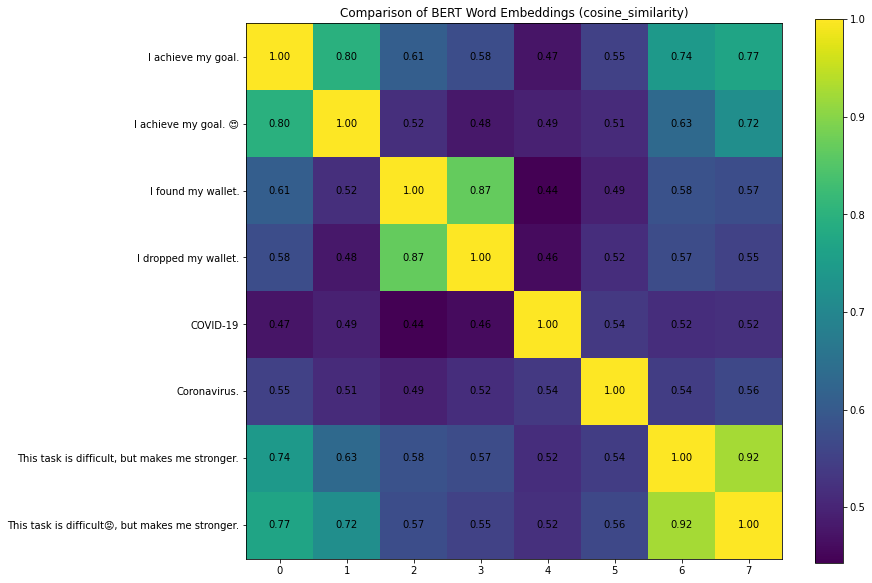

```python
def cosine_similarity(a, b):
    # Compute cosine similarity between two numpy vectors a and b
    return (a @ b)/(a@a * b@b)**0.5

similarity_matrix = pairwise_distances(cls_embeddings, metric=cosine_similarity)

##### Plot the similarity matrix #####
plt.rcParams['figure.figsize'] = [12, 10] # Change figure size of the plot
plt.imshow(similarity_matrix) # Display an image in the plot
plt.colorbar() # Add colorbar to the plot
plt.yticks(ticks=range(len(sentences)), labels=sentences) # Set tick locations and labels (sentences) of y-axis
plt.title('Comparison of BERT Word Embeddings (cosine_similarity)') # Add title to the plot
for (i,j), label in np.ndenumerate(similarity_matrix): # np.ndenumerate is 2D version of enumerate
    plt.text(i, j, '{:.2f}'.format(label), ha='center', va='center') # Add values in similarity_matrix to the corresponding position in the plot
plt.show() # Show the plot
```

## bert-base-multilingual-uncased-sentiment

```python
import os
os.environ["TOKENIZERS_PARALLELISM"] = "false"
```

```python
!pip install transformers==4.5.0
import random
from transformers import BertModel, BertTokenizerFast

# Fix random seed for reproducibility
def same_seeds(seed):
    torch.manual_seed(seed)
    if torch.cuda.is_available():
        torch.cuda.manual_seed(seed)
        torch.cuda.manual_seed_all(seed)
    np.random.seed(seed)
    random.seed(seed)
    torch.backends.cudnn.benchmark = False
    torch.backends.cudnn.deterministic = True

same_seeds(0)
```

```python
sentences = [
    "I achieve my goal.",
    "I achieve my goal. 😍",
    "I found my wallet.",
    "I dropped my wallet.",
    "COVID-19.",
    "Coronavirus.",
    "This task is difficult, but makes me stronger.",
    "This task is difficult😡, but makes me stronger."
]
```

```python
model = BertModel.from_pretrained('nlptown/bert-base-multilingual-uncased-sentiment', output_hidden_states=True).eval()
tokenizer = BertTokenizerFast.from_pretrained('nlptown/bert-base-multilingual-uncased-sentiment')
```

```python
tokenized_sentences = [tokenizer(sentence, return_tensors='pt') for sentence in sentences]
with torch.no_grad():
    emb_sentences = [model(**tokenized_sentence).hidden_states[12][0].detach().numpy() for tokenized_sentence in tokenized_sentences]

emb_sentences[0].shape # 8 sentences
```

```
(7, 768)
```

```python
cls_embeddings = np.stack([emb_sentence[0] for emb_sentence in emb_sentences])
cls_embeddings.shape
```

```
(8, 768)
```

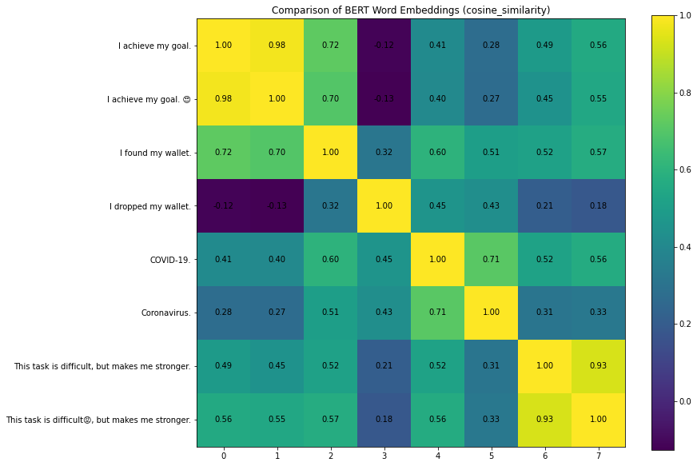

```python
def cosine_similarity(a, b):
    # Compute cosine similarity between two numpy vectors a and b
    return (a @ b)/(a@a * b@b)**0.5

similarity_matrix = pairwise_distances(cls_embeddings, metric=cosine_similarity)

##### Plot the similarity matrix #####
plt.rcParams['figure.figsize'] = [12, 10] # Change figure size of the plot
plt.imshow(similarity_matrix) # Display an image in the plot
plt.colorbar() # Add colorbar to the plot
plt.yticks(ticks=range(len(sentences)), labels=sentences) # Set tick locations and labels (sentences) of y-axis
plt.title('Comparison of BERT Word Embeddings (cosine_similarity)') # Add title to the plot
for (i,j), label in np.ndenumerate(similarity_matrix): # np.ndenumerate is 2D version of enumerate
    plt.text(i, j, '{:.2f}'.format(label), ha='center', va='center') # Add values in similarity_matrix to the corresponding position in the plot
plt.show() # Show the plot
```

# Conclusion and Preprocesses

# Sentiment Analysis - Time Trend

```python
with open(f'df_{dataFiles[0]}.pickle', 'rb') as f:
    news_preElection = pickle.load(f)
with open(f'df_{dataFiles[1]}.pickle', 'rb') as f:
    news_postElection = pickle.load(f)
```

```python
news_preElection.sample(5)
```

|  | Date | AuthorID | Content | URL | AuthorName | emb | ContentSenti | emb_based_on_senti |
| --- | --- | --- | --- | --- | --- | --- | --- | --- |
| 2653 | 2020-09-10 12:24:02 | 1 | China hits back at a US decision to revoke vis... | https://t.co/ZaolZsNixx | NBCNews | [0.10284613, 0.018287398, 0.1649949, 0.3675799... | -0.549466 | [-0.32243502, 0.41605496, -0.04747437, -0.2998... |
| 2748 | 2020-05-06 04:30:08 | 4 | The Trump administration s accusations that Ch... | https://t.co/SQmlHCICjR | CNN | [0.04053883, 0.04571393, 0.35815755, 0.1057855... | -0.898693 | [-0.29124525, 0.14868268, 0.074623846, -0.6433... |
| 3718 | 2020-10-23 06:00:05 | 0 | Bearing the brunt of the costs of the technolo... | https://t.co/6HWguBLBb7 | WSJ | [0.38957307, -0.018117107, 0.86004233, 0.25895... | -0.787823 | [-0.00022200782, -0.0126123885, -0.1648506, -0... |
| 467 | 2020-09-27 21:45:00 | 0 | Chinas Commerce Ministry signaled that a black... | https://t.co/U640YYr3pF | WSJ | [0.21928774, 0.44442344, 0.24292657, 0.5920476... | -0.111363 | [-0.16728216, 0.20842353, 0.02422982, -0.43135... |
| 3444 | 2020-06-24 02:20:00 | 0 | @WSJheard Heard on the Street Europe is broadl... | https://t.co/9h4CCrSSi5 | WSJ | [0.031209443, 0.13420594, 0.13663828, 0.278091... | -0.032134 | [0.0069960468, -0.019858027, -0.04309795, -0.3... |

```python
news_postElection.sample(5)
```

|  | Date | AuthorID | Content | URL | AuthorName | emb | ContentSenti | emb_based_on_senti |
| --- | --- | --- | --- | --- | --- | --- | --- | --- |
| 297 | 2021-01-05 20:49:54 | 0 | China regulators are trying to get Jack Ma to ... | https://t.co/WS4yX2JC6e | WSJ | [0.16541857, 0.30842432, 0.20673162, 0.3932112... | -0.196480 | [-0.19779843, 0.04960383, -0.03297598, -0.3001... |
| 1857 | 2021-02-16 14:44:02 | 1 | The WHO s Covid 19 fact finding mission has be... | https://t.co/d0ABSyd8w9 | NBCNews | [0.11058389, -0.09351457, 0.35428727, 0.041692... | -0.472462 | [-0.3672771, 0.12727192, -0.096464925, -0.1090... |
| 924 | 2021-01-10 20:45:00 | 2 | An infrared camera set in a Nature Reserve in ... | https://t.co/XnVwXriXw6 | CBSNews | [0.6062661, 0.66504323, -0.13786772, 0.6773466... | 0.836255 | [-0.23426726, -0.5408104, 0.23572029, 0.041860... |
| 988 | 2021-11-03 10:18:54 | 3 | Foreign technology firms have been pulling out... | https://t.co/927oy05LXs | ABC | [0.37223533, 0.21957967, 0.34098357, 0.266818,... | -0.299481 | [-0.27521706, 0.21160296, -0.047517754, -0.239... |
| 854 | 2021-04-22 02:00:25 | 1 | China is behind a newly discovered series of h... | https://t.co/sZ4yeGa0iz | NBCNews | [0.5299646, 0.113354556, 0.66238445, 0.0417598... | -0.568713 | [-0.37880257, 0.027291719, 0.20693451, -0.2262... |

## histogram

### preElection

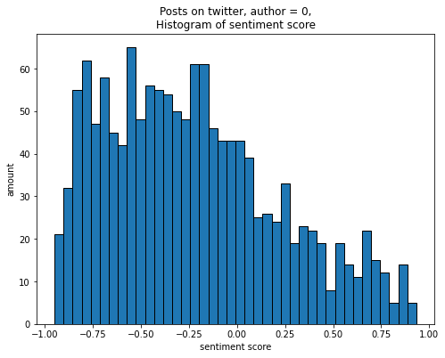

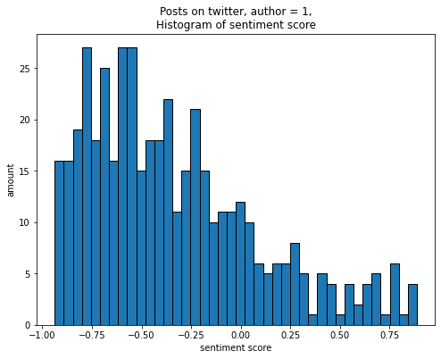

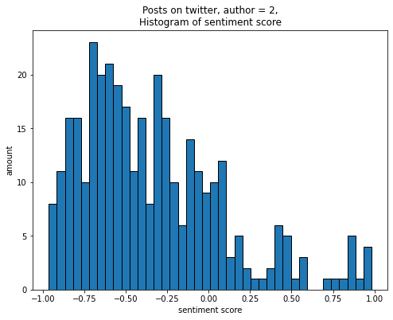

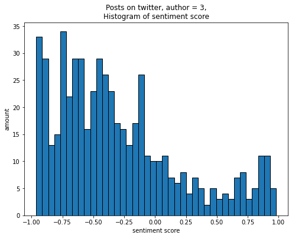

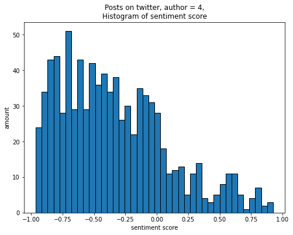

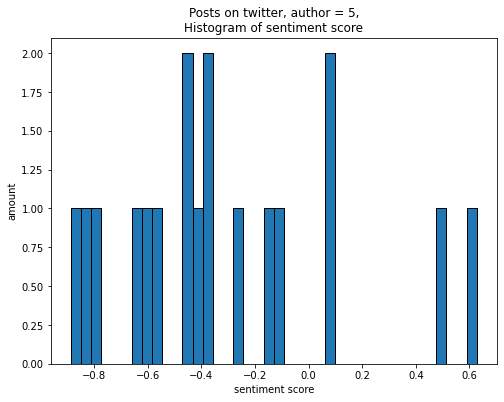

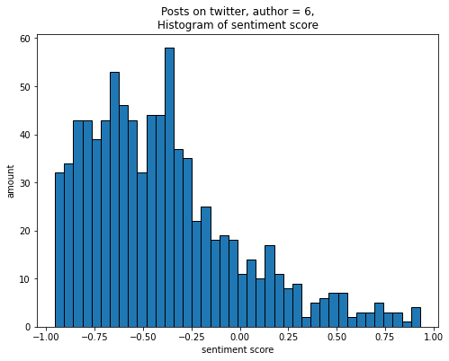

```python
plt.rcParams['figure.figsize'] = [8, 6]
for authorID in set(news_preElection.AuthorID):
    # print(f'=========== author = {authorID} ============')
    # print(news_preElection[news_preElection.AuthorID == authorID]\
    #       .ContentSenti.describe())
    # print('===================================')
    plt.hist(news_preElection[news_preElection.AuthorID == authorID].ContentSenti, \
              bins = 40, histtype = 'bar',ec='black')
    plt.title(f'Posts on twitter, author = {authorID},\nHistogram of sentiment score')

    plt.xlabel('sentiment score')

    plt.ylabel('amount')
    plt.show()
```

### postElection

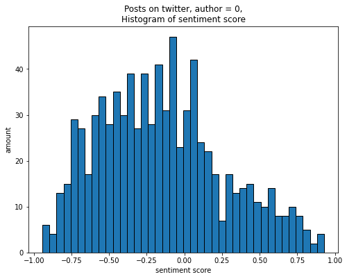

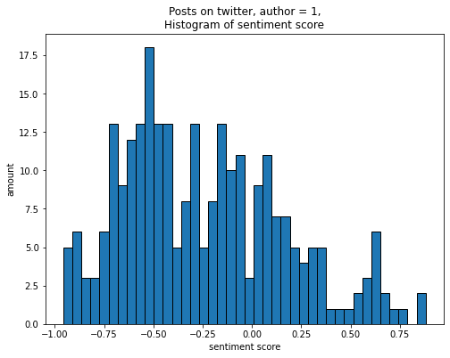

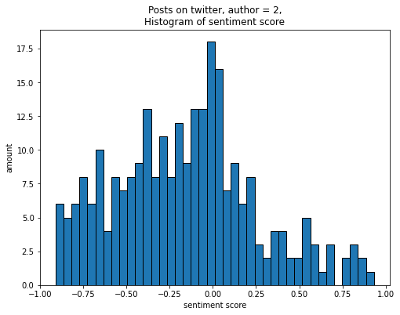

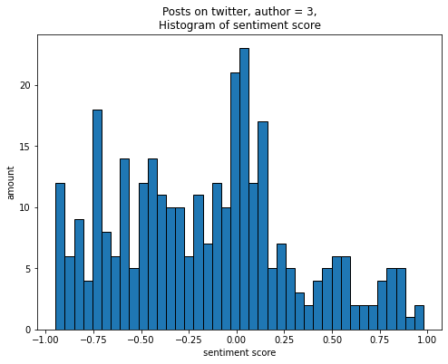

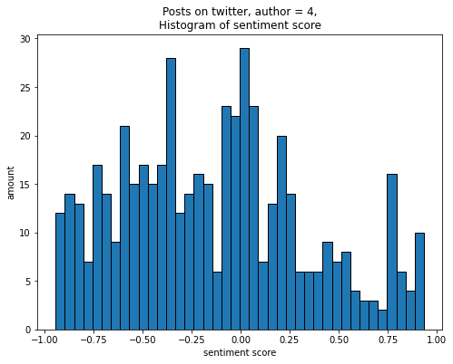

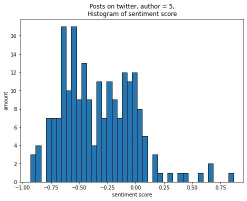

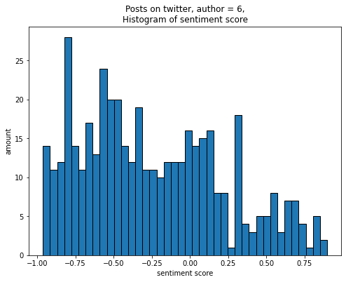

```python
plt.rcParams['figure.figsize'] = [8, 6]
for authorID in set(news_postElection.AuthorID):
    # print(f'=========== author = {authorID} ============')
    # print(news_postElection[news_postElection.AuthorID == authorID]\
    #       .ContentSenti.describe())
    # print('===================================')
    plt.hist(news_postElection[news_postElection.AuthorID == authorID].ContentSenti, \
              bins = 40, histtype = 'bar',ec='black')
    plt.title(f'Posts on twitter, author = {authorID},\nHistogram of sentiment score')

    plt.xlabel('sentiment score')

    plt.ylabel('amount')
    plt.show()
```

## Statistics of preEletion & postElection

```python
series = []
for authorID in set(news_preElection.AuthorID):
    series.append(news_preElection[news_preElection.AuthorID == authorID]\
          .ContentSenti.describe())
stats_pre = pd.DataFrame(series)
stats_pre.index = list(set(news_preElection.AuthorID))


series = []
for authorID in set(news_postElection.AuthorID):
    series.append(news_postElection[news_postElection.AuthorID == authorID]\
          .ContentSenti.describe())
stats_post = pd.DataFrame(series)
stats_post.index = list(set(news_postElection.AuthorID))

meanDiff = pd.DataFrame([stats_post["mean"] - stats_pre["mean"], stats_post["50%"] - stats_pre["50%"]]).T
meanDiff.columns = ["mean-difference", "median-difference"]
```

```python
stats_pre
```

|  | count | mean | std | min | 25% | 50% | 75% | max |
| --- | --- | --- | --- | --- | --- | --- | --- | --- |
| 0 | 1390.0 | -0.232721 | 0.448396 | -0.950478 | -0.589169 | -0.287991 | 0.045140 | 0.933484 |
| 1 | 454.0 | -0.340700 | 0.428685 | -0.937678 | -0.677305 | -0.428266 | -0.098566 | 0.888076 |
| 2 | 346.0 | -0.346304 | 0.427992 | -0.965744 | -0.669747 | -0.424618 | -0.097102 | 0.983133 |
| 3 | 556.0 | -0.299903 | 0.502973 | -0.962231 | -0.688930 | -0.417434 | -0.053500 | 0.979577 |
| 4 | 867.0 | -0.340085 | 0.422301 | -0.962758 | -0.685311 | -0.404634 | -0.079457 | 0.925371 |
| 5 | 18.0 | -0.312224 | 0.423108 | -0.886151 | -0.593651 | -0.398364 | -0.119203 | 0.627023 |
| 6 | 859.0 | -0.399950 | 0.391027 | -0.955051 | -0.691186 | -0.460182 | -0.208821 | 0.931437 |

```python
stats_post
```

|  | count | mean | std | min | 25% | 50% | 75% | max |
| --- | --- | --- | --- | --- | --- | --- | --- | --- |
| 0 | 825.0 | -0.153745 | 0.411572 | -0.943025 | -0.470285 | -0.181533 | 0.090607 | 0.927249 |
| 1 | 263.0 | -0.244263 | 0.410580 | -0.956848 | -0.565975 | -0.294901 | 0.046743 | 0.880903 |
| 2 | 265.0 | -0.163430 | 0.409092 | -0.909756 | -0.468034 | -0.169866 | 0.062229 | 0.931455 |
| 3 | 324.0 | -0.158066 | 0.466846 | -0.948324 | -0.527017 | -0.143487 | 0.114918 | 0.979577 |
| 4 | 503.0 | -0.135486 | 0.474095 | -0.941773 | -0.514112 | -0.154001 | 0.162767 | 0.934875 |
| 5 | 211.0 | -0.336142 | 0.316181 | -0.929770 | -0.582747 | -0.350928 | -0.105833 | 0.864796 |
| 6 | 447.0 | -0.244505 | 0.465497 | -0.962628 | -0.610514 | -0.328074 | 0.092972 | 0.897593 |

```python
meanDiff
```

|  | mean-difference | median-difference |
| --- | --- | --- |
| 0 | 0.078976 | 0.106458 |
| 1 | 0.096436 | 0.133364 |
| 2 | 0.182874 | 0.254752 |
| 3 | 0.141837 | 0.273947 |
| 4 | 0.204599 | 0.250633 |
| 5 | -0.023918 | 0.047436 |
| 6 | 0.155446 | 0.132107 |

- After election, the sentiment with respect to `China` is more positive.

## scotter plot

```python
import datetime as dt
from sklearn import linear_model
from sklearn.feature_selection import f_regression

def shiftdate(startDate, days):
    return startDate + dt.timedelta(days=days)
def getRegressionCoef(startDate, endDate, Series_keyDate):
    Y = Series_keyDate.iloc[(Series_keyDate.index >= startDate) & (Series_keyDate.index <= endDate)]
    X = [(d - startDate).days for d in Series_keyDate.index  if (d >= startDate and d <= endDate)]
    regr = linear_model.LinearRegression()
    regr.fit(np.array(X).reshape(-1, 1),Y)

    return {"X":[shiftdate(startDate,X[0]),shiftdate(startDate,X[-1])],
            "Y":np.array([X[0], X[-1]]) *regr.coef_[0] + regr.intercept_,
            "coef":regr.coef_[0],
            "bias":regr.intercept_,
            "t":f_regression(np.array(X).reshape(-1, 1),Y)[1][0]}
```

```python
news_crossElection = news_preElection.append(news_postElection).reset_index()
```

```python
groupby_news = news_crossElection.groupby([news_crossElection.AuthorID,news_crossElection.Date.map(lambda t:t.date())])["ContentSenti"]
```

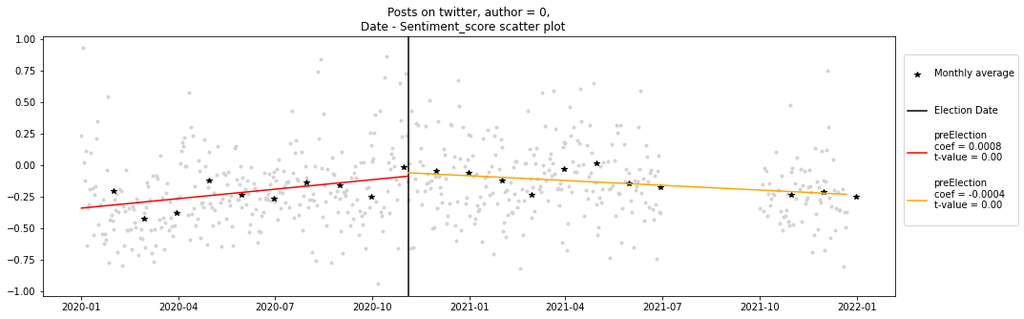

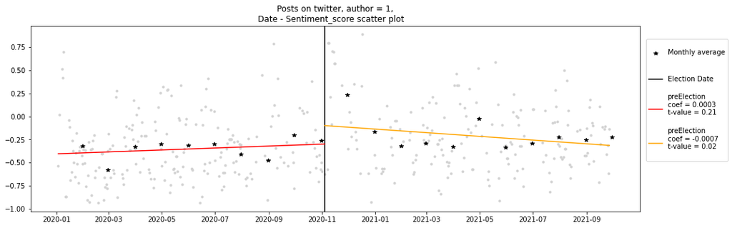

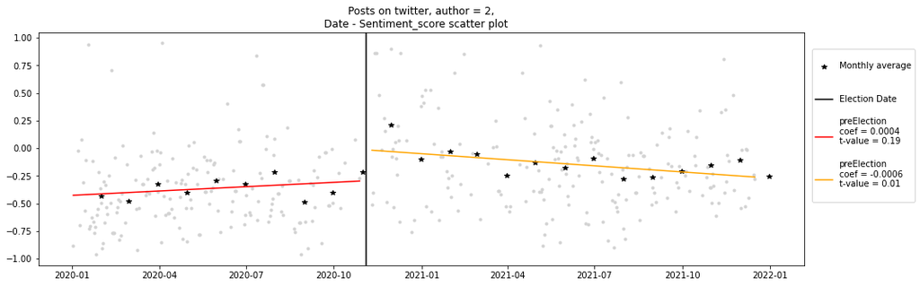

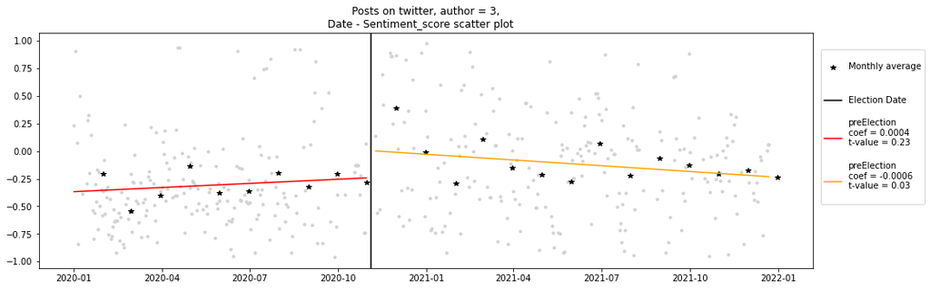

[figure not shown]

[figure not shown]

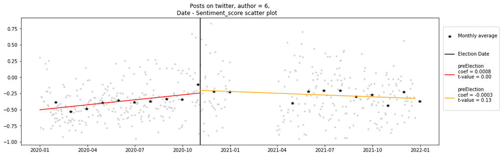

```python
plt.rcParams['figure.figsize'] = [16, 5]
startDate = news_crossElection.Date.min().date()
endDate = news_crossElection.Date.max().date()
electionSep = "2020-11-04"
electionSepDate = dt.datetime.strptime(electionSep,"%Y-%m-%d").date()

for authorID in set(news_crossElection.AuthorID):
    plt.plot(groupby_news.agg('mean').loc[authorID], ".", color = "lightgray")
    plt.title(f'Posts on twitter, author = {authorID},\nDate - Sentiment_score scatter plot   ')

    _monthdata = groupby_news.agg('mean').loc[authorID]
    _monthdata.index = pd.to_datetime(_monthdata.index)
    plt.plot(_monthdata.groupby(pd.Grouper(freq='M')).agg('mean'), "*",
             color ="black",
             label = "\nMonthly average\n")

    plt.axvline(electionSepDate,
                linestyle = "-",
                color = "black",
                label = "\nElection Date\n")

    regrinfo = getRegressionCoef(startDate,
                      electionSepDate,
                      groupby_news.agg('mean').loc[authorID])
    plt.plot(regrinfo["X"],
             regrinfo["Y"],
             color = "red",
             label = f"preElection\ncoef = {regrinfo['coef']:.4f}\nt-value = {regrinfo['t']:.2f}\n")


    regrinfo = getRegressionCoef(electionSepDate,
                      endDate,
                      groupby_news.agg('mean').loc[authorID])
    plt.plot(regrinfo["X"],
             regrinfo["Y"],
             color = "orange",
             label = f"preElection\ncoef = {regrinfo['coef']:.4f}\nt-value = {regrinfo['t']:.2f}\n")


    plt.legend(bbox_to_anchor=(1.15, 0.95))

    # plt.hist(df.agg('mean').loc[i],bins=40)
    # plt.xlim(pre.Date.min(),pre.Date.max())
    # plt.ylim(-1,1)
    # plt.xticks(rotation=45)
    # plt.xlabel('date')
    # plt.yticks(rotation=45)
    # plt.ylabel('value')
    # plt.yticks(rotation=0)
    plt.show()
```

# Cluster

Can we explore some information from cluster model?

```python
from sklearn.feature_extraction.text import TfidfVectorizer
from sklearn.cluster import KMeans
```

```python
# TFIDF
TFIDF_vectorizer = TfidfVectorizer(min_df = 3, stop_words='english')
TFIDF_vec_news = TFIDF_vectorizer.fit_transform(news_crossElection.Content)
```

```python
TFIDF_vec_news.shape
```

```
(7328, 5709)
```

```python
n_clusters = 8
cost = []
for n in range(2, n_clusters):
    kmeans = KMeans(n_clusters = n)
    kmeans.fit(TFIDF_vec_news)
    cost.append(kmeans.inertia_)
```

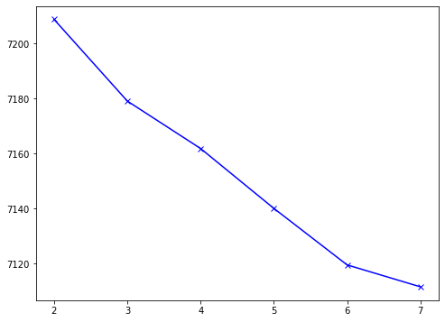

```python
plt.rcParams['figure.figsize'] = [8, 6]
plt.plot(range(2, n_clusters),cost,  "bx-")
plt.show()
```

- choose K = 6

```python
finalK = 6
kmeans = KMeans(n_clusters = finalK)
kmeans.fit(TFIDF_vec_news)
```

```
KMeans(n_clusters=6)
```

```python
result = pd.DataFrame(
    np.hstack(
        [news_crossElection.AuthorID.to_numpy().reshape(-1,1),
         kmeans.labels_.reshape(-1,1)]
    ), columns = ["real", "cluster_pred"]
)
```

```python
# create mapping
mapping = {} # {real: pred}
for real in set(news_crossElection.AuthorID):
    curPred = result[result.real == real].cluster_pred
    curDistribution = [0.0]*finalK
    for prediciton in curPred:
        curDistribution[prediciton] += 1/len(curPred)
    mapping[real] = curDistribution.copy()
mapping = pd.DataFrame(mapping).T
mapping # [real, pred] = [0~6, 0~5]
```

|  | 0 | 1 | 2 | 3 | 4 | 5 |
| --- | --- | --- | --- | --- | --- | --- |
| 0 | 0.085327 | 0.060948 | 0.040632 | 0.045147 | 0.688939 | 0.079007 |
| 1 | 0.220363 | 0.043236 | 0.059972 | 0.086471 | 0.482566 | 0.107392 |
| 2 | 0.175123 | 0.044190 | 0.026187 | 0.060556 | 0.576105 | 0.117840 |
| 3 | 0.237500 | 0.050000 | 0.048864 | 0.085227 | 0.518182 | 0.060227 |
| 4 | 0.244526 | 0.053285 | 0.059854 | 0.047445 | 0.504380 | 0.090511 |
| 5 | 0.030568 | 0.004367 | 0.039301 | 0.082969 | 0.615721 | 0.227074 |
| 6 | 0.195253 | 0.076570 | 0.059724 | 0.020674 | 0.545176 | 0.102603 |

Our data is scraped with the respect to `China`... From the table above, it seems that cluster model cannot interpret anything.

# More evidence to show difference in data

```python
from sklearn.preprocessing import normalize
```

```python
for i in range(7):
    print(f"ID = {i}:",news_crossElection[news_crossElection.AuthorID == i].AuthorName.iloc[0])
```

```
ID = 0: WSJ
ID = 1: NBCNews
ID = 2: CBSNews
ID = 3: ABC
ID = 4: CNN
ID = 5: FoxNews
ID = 6: nytimes
```

## Explore Text's cosine_sim with TFIDF

```python
# TFIDF
TFIDF_vectorizer = TfidfVectorizer(min_df = 2, stop_words='english',lowercase=True)
TFIDF_vectorizer.fit(news_crossElection.Content)
TFIDF_vec_news_pre = TFIDF_vectorizer.transform(news_preElection.Content)
TFIDF_vec_news_post = TFIDF_vectorizer.transform(news_postElection.Content)
```

```python
for author in set(news_crossElection.AuthorID):
    dataset1 = normalize(TFIDF_vec_news_pre[news_preElection.AuthorID == author])
    dataset2 = normalize(TFIDF_vec_news_post[news_postElection.AuthorID == author])

    print(f"For AuthorID == {author},")
    print(f"    CosineSim(pre, pre)   = {(dataset1 @ dataset1.T).mean() :.4f}")
    print(f"    CosineSim(pre, post)  = {(dataset1 @ dataset2.T).mean() :.4f}")
    print(f"    CosineSim(post, post) = {(dataset2 @ dataset1.T).mean() :.4f}")
```

```
For AuthorID == 0,
    CosineSim(pre, pre)   = 0.0117
    CosineSim(pre, post)  = 0.0092
    CosineSim(post, post) = 0.0092
For AuthorID == 1,
    CosineSim(pre, pre)   = 0.0214
    CosineSim(pre, post)  = 0.0106
    CosineSim(post, post) = 0.0106
For AuthorID == 2,
    CosineSim(pre, pre)   = 0.0193
    CosineSim(pre, post)  = 0.0088
    CosineSim(post, post) = 0.0088
For AuthorID == 3,
    CosineSim(pre, pre)   = 0.0209
    CosineSim(pre, post)  = 0.0089
    CosineSim(post, post) = 0.0089
For AuthorID == 4,
    CosineSim(pre, pre)   = 0.0206
    CosineSim(pre, post)  = 0.0107
    CosineSim(post, post) = 0.0107
For AuthorID == 5,
    CosineSim(pre, pre)   = 0.0704
    CosineSim(pre, post)  = 0.0114
    CosineSim(post, post) = 0.0114
For AuthorID == 6,
    CosineSim(pre, pre)   = 0.0169
    CosineSim(pre, post)  = 0.0102
    CosineSim(post, post) = 0.0102
```

- Because of data sparsity, there is no similarity between posts represented by TFIDF vector.

## Explore Text's cosine_sim with embeddings

- emb $\Rightarrow$ keras_bert ,dim = $(n,768)$
- emb_based_on_senti $\Rightarrow$ bert-base-multilingual-uncased-sentiment, dim = $(n,768)$

```python
preElectionX = np.hstack([
    np.stack(news_preElection.emb), np.stack(news_preElection.emb_based_on_senti)]
)

# preElectionX:
# [ emb(768), emb_based_on_senti(768) ]
# [ emb(768), emb_based_on_senti(768) ]
#                 ...
preElectionX.shape # (n, 768+768)
```

```
(4490, 1536)
```

```python
preElectionY = np.zeros(
    (news_preElection.shape[0],
     len(set(news_preElection.AuthorID)))
)
for index, item in enumerate(news_preElection.AuthorID):
    preElectionY[index][item] = 1
preElectionY # (n, 7)
```

```
array([[0., 0., 1., ..., 0., 0., 0.],
       [0., 0., 1., ..., 0., 0., 0.],
       [0., 0., 1., ..., 0., 0., 0.],
       ...,
       [0., 0., 0., ..., 1., 0., 0.],
       [0., 0., 0., ..., 1., 0., 0.],
       [0., 0., 0., ..., 1., 0., 0.]])
```

```python
# post
postElectionX = np.hstack([
    np.stack(news_postElection.emb), np.stack(news_postElection.emb_based_on_senti)]
)
postElectionY = np.zeros(
    (news_postElection.shape[0],
     len(set(news_postElection.AuthorID)))
)
for index, item in enumerate(news_postElection.AuthorID):
    postElectionY[index][item] = 1
```

```python
preElectionX.shape, preElectionY.shape
```

```
((4490, 1536), (4490, 7))
```

```python
postElectionX.shape, postElectionY.shape
```

```
((2838, 1536), (2838, 7))
```

```python
for author in set(news_crossElection.AuthorID):
    dataset1 = normalize(preElectionX[news_preElection.AuthorID == author])
    dataset2 = normalize(postElectionX[news_postElection.AuthorID == author])

    print(f"For AuthorID == {author},")
    print(f"    CosineSim(pre, pre)   = {(dataset1 @ dataset1.T).mean() :.4f}")
    print(f"    CosineSim(pre, post)  = {(dataset1 @ dataset2.T).mean() :.4f}")
    print(f"    CosineSim(post, post) = {(dataset2 @ dataset2.T).mean() :.4f}")
```

```
For AuthorID == 0,
    CosineSim(pre, pre)   = 0.6928
    CosineSim(pre, post)  = 0.6895
    CosineSim(post, post) = 0.6902
For AuthorID == 1,
    CosineSim(pre, pre)   = 0.6968
    CosineSim(pre, post)  = 0.6760
    CosineSim(post, post) = 0.6772
For AuthorID == 2,
    CosineSim(pre, pre)   = 0.6834
    CosineSim(pre, post)  = 0.6582
    CosineSim(post, post) = 0.6522
For AuthorID == 3,
    CosineSim(pre, pre)   = 0.6703
    CosineSim(pre, post)  = 0.6590
    CosineSim(post, post) = 0.6688
For AuthorID == 4,
    CosineSim(pre, pre)   = 0.6978
    CosineSim(pre, post)  = 0.6697
    CosineSim(post, post) = 0.6647
For AuthorID == 5,
    CosineSim(pre, pre)   = 0.7240
    CosineSim(pre, post)  = 0.7062
    CosineSim(post, post) = 0.7153
For AuthorID == 6,
    CosineSim(pre, pre)   = 0.6933
    CosineSim(pre, post)  = 0.6755
    CosineSim(post, post) = 0.6714
```

$\Rightarrow$ `similarity(pre,post)` $\approx$ `similarity(pre,pre)` $\approx$ `similarity(post,post)`

## DNN model

Since the `similarity(pre,post)` $\approx$ `similarity(pre,pre)` $\approx$ `similarity(post,post)`, we can conclude that the `writing-style` of every news is invariant over time.

Training a deep-model with `80% preElection` data, we expect the model can predict `postElection` behavior as well as `another 20% preElection` behavior.

```python
from keras.models import Sequential
from keras.layers import Flatten, Dense, Embedding, LSTM, Dropout
from keras import callbacks
from sklearn.svm import SVC
from sklearn import metrics
from sklearn.model_selection import train_test_split
```

```python
x_train, x_valid, y_train, y_valid = train_test_split(preElectionX, preElectionY, test_size = 0.2)
```

```python
callback = callbacks.EarlyStopping(monitor='loss', patience=20) # Early Stop
model = Sequential()
model.add(Dense(1024, activation = 'relu', input_shape = (preElectionX.shape[1],)))
model.add(Dropout(0.7))
model.add(Dense(256, activation = 'relu'))
model.add(Dropout(0.5))
model.add(Dense(64, activation = 'relu'))
model.add(Dense(preElectionY.shape[1], activation = 'sigmoid'))
model.compile(loss='binary_crossentropy', optimizer='Adam', metrics = ['accuracy'])
```

```python
model.summary()
```

```
Model: "sequential_3"
_________________________________________________________________
 Layer (type)                Output Shape              Param #
=================================================================
 dense_5 (Dense)             (None, 1024)              1573888

 dropout_2 (Dropout)         (None, 1024)              0

 dense_6 (Dense)             (None, 256)               262400

 dropout_3 (Dropout)         (None, 256)               0

 dense_7 (Dense)             (None, 64)                16448

 dense_8 (Dense)             (None, 7)                 455

=================================================================
Total params: 1,853,191
Trainable params: 1,853,191
Non-trainable params: 0
_________________________________________________________________
```

```python
model.fit(x_train, y_train, epochs = 400, callbacks = [callback], verbose = 0)
```

```
<keras.callbacks.History at 0x7fdadf6c9070>
```

```python
y_valid_hat = model.predict(x_valid)

print("Validation (on preElection) information is shown below:")
print(metrics.classification_report(y_valid.argmax(axis = 1), y_valid_hat.argmax(axis = 1),  zero_division = 0))
```

```
Validation (on preElection) information is shown below:
              precision    recall  f1-score   support

           0       0.80      0.83      0.81       277
           1       0.62      0.70      0.66        89
           2       0.85      0.75      0.79        67
           3       0.75      0.66      0.70       120
           4       0.65      0.68      0.66       183
           5       0.00      0.00      0.00         4
           6       0.60      0.59      0.60       158

    accuracy                           0.71       898
   macro avg       0.61      0.60      0.60       898
weighted avg       0.71      0.71      0.71       898
```

```python
post_y_valid_hat = model.predict(postElectionX)

print("Testing (on postElection) information is shown below:")
print(metrics.classification_report(postElectionY.argmax(axis = 1), post_y_valid_hat.argmax(axis = 1),  zero_division = 0))
```

```
Testing (on postElection) information is shown below:
              precision    recall  f1-score   support

           0       0.72      0.74      0.73       825
           1       0.39      0.36      0.38       263
           2       0.35      0.46      0.40       265
           3       0.40      0.43      0.41       324
           4       0.52      0.44      0.48       503
           5       1.00      0.03      0.06       211
           6       0.49      0.67      0.57       447

    accuracy                           0.53      2838
   macro avg       0.55      0.45      0.43      2838
weighted avg       0.57      0.53      0.51      2838
```

The model is not robust for predicting `postElection` behavior.

Under controlling of `writing-style` , there still exists differences between pre & post-election data.

## Data Distribution

Maybe... there exits semantic/topic differences between datasets

```python
def findTopN_more_freq(featureName, TFIDF_Matrix, N):
    """
    return top N important words of a dataset
    """
    ind = np.argsort(TFIDF_Matrix.toarray().sum(axis = 0))[::-1][0:N]
    return (np.array(featureName)[ind])
```

```python
topN = 30
```

```python
importantPre = findTopN_more_freq(TFIDF_vectorizer.get_feature_names(), TFIDF_vec_news_pre, topN)
importantPre
```

```
array(['china', 'coronavirus', 'new', 'outbreak', 'chinas', 'people',
       'cases', 'wuhan', 'trump', 'hong', 'kong', 'chinese', 'president',
       'virus', 'health', 'said', 'world', 'pandemic', 'trade', 'death',
       'says', 'officials', 'country', 'spread', 'latest', 'countries',
       'state', 'beijing', 'reported', 'global'], dtype='<U19')
```

```python
importantPost = findTopN_more_freq(TFIDF_vectorizer.get_feature_names(), TFIDF_vec_news_post, topN)
importantPost
```

```
array(['china', 'biden', 'chinas', 'covid', 'chinese', 'new', 'says',
       'country', 'beijing', '19', 'president', 'said', 'world', 'taiwan',
       'year', 'xi', 'russia', 'space', 'climate', 'global', 'people',
       'government', 'years', 'military', 'administration', 'jinping',
       'state', 'foreign', 'analysis', 'origins'], dtype='<U19')
```

```python
interSection = set(importantPre).intersection(set(importantPost))
np.array(list(interSection))
```

```
array(['chinas', 'new', 'president', 'beijing', 'state', 'world',
       'global', 'chinese', 'says', 'country', 'people', 'china', 'said'],
      dtype='<U9')
```

```python
topicIntersectRatio = np.array(list(interSection)).shape[0]/topN
print(f"Two dataset shares {topicIntersectRatio:.3f} of topic.")
```

```
Two dataset shares 0.433 of topic.
```

# Conclusion

There exists difference between `preElection's` & `postElection's` behavior.

Maybe because of:

- difference in sentiment
- difference in posts' distribution